# Assignment: OLS Regression

Jon Doretti

2024-06-11 21:08:34

# Instructions

This assignment reviews the *OLS Regression* content. You will use the **ols_regression.Rmd** file I reviewed as part of the lectures for this week to complete this assignment. You will *copy and paste* relevant code from that file and update it to answer the questions in this assignment. You will respond to questions in each section after executing relevant code to answer a question. You will submit this assignment to its *Submissions* folder on *D2L*. You will submit *two* files:

1. this completed *R Markdown* script, and
2. an *HTML* rendered version of it to *D2L*.

To start:

First, create a folder on your computer to save all relevant files for this course. If you did not do so already, you will want to create a folder named **mgt_585** that contains all of the materials for this course.

Second, inside of **mgt_585**, you will create a folder to host assignments. You can name that folder **assignments**. Inside the **assignments** folder, you can create a folder for topic assignments named: **topics**.

Third, inside of the **topics** folder, you will create folders for each assignment. You can name the folder for this assignment: **05_ols_regression**.

Fourth, create two additional folders in **05_ols_regression** named **scripts**, **data**, and **plots**. Store this script in the **scripts** folder and the data for this assignment in the **data** folder.

Fifth, go to the *File* menu in *RStudio*, select *New Project…*, choose *Existing Directory*, go to your */mgt_585/assignments/topics/05_ols_regression* folder to select it as the top-level directory for this *R Project*.

# Global Settings

The first code chunk sets the global settings for the remaining code chunks in the document. Do *not* change anything in this code chunk.

# Activate Packages

In this code chunk, we load the following packages:

1. [here](https://here.r-lib.org);
2. [tidyverse](https://www.tidyverse.org);
3. [skimr](https://docs.ropensci.org/skimr/);
4. [scales](https://scales.r-lib.org);
5. [snakecase](https://tazinho.github.io/snakecase/);
6. [fst](https://www.fstpackage.org);
7. [broom](https://broom.tidymodels.org);
8. [interactions](https://interactions.jacob-long.com);
9. [jtools](https://jtools.jacob-long.com/index.html);
10. [sandwich](https://sandwich.r-forge.r-project.org/index.html).

Make sure you installed these packages when you reviewed the analytical lecture.

We will use functions from these packages to examine the data. Do *not* change anything in this code chunk.

```r
## here for project workflow
library(here)

## tidyverse for data manipulation and plotting;
## loads eight different libraries simultaneously
library(tidyverse)

## skimr to summarize data
library(skimr)

## scales for variable scales
library(scales)

## snakecase for naming conventions
library(snakecase)

## fst to import fst data files
library(fst)

## broom to examine output from statistical models
library(broom)

## interactions to visualize interaction effects in regression models
library(interactions)

## jtools to summarize regression model results
library(jtools)

## sandwich for robust standard errors
library(sandwich)
```

# Task 1: Import Data

We will use the same data as in the analytical lecture: **auction.fst**. After you load the data, then you will execute other commands on the data.

## Task 1.1

Use the **read_fst()** and **here()** functions to load the data file for this working session. Save the data as the object **auction_raw**.

Examine **auction_raw** with **glimpse()**.

**Question 1.1**: Answer these questions: (1) How many *observations* are there in the *raw* data? (2) How many *variables* are there in the *raw* data? c **Response 1.1**: (1) 627 (2) 8

```r
# Assuming your data file is named "auction_data.fst" and is located in the working directory
auction_raw <- read_fst(here("data", "auction.fst"))

# Examine the structure of auction_raw
glimpse(auction_raw)
```

```
## Rows: 627
## Columns: 8
## $ auctionId   <dbl> 1638843936, 1638844284, 1638844464, 1638844729, 1638893549…
## $ bid         <dbl> 3550.00, 1300.00, 1780.00, 940.00, 655.00, 750.00, 3750.00…
## $ bidTime     <dbl> 6.89, 1.25, 7.00, 7.00, 2.91, 7.00, 6.36, 6.97, 5.56, 1.79…
## $ bidderRate  <dbl> 9.5, 37.5, 9.5, 86.5, 8.5, 9.5, 8.5, 10.5, 12.5, 49.5, 29.…
## $ openBid     <dbl> 710.64, 324.56, 447.46, 508.71, 377.70, 251.52, 663.61, 48…
## $ price       <dbl> 7316.87, 2557.03, 4816.48, 2911.76, 1495.36, 1153.17, 7468…
## $ item        <chr> "Cartier wristwatch", "Cartier wristwatch", "Cartier wrist…
## $ auctionType <chr> "7 day auction", "7 day auction", "7 day auction", "7 day …
```

# Task 2: Clean Data

In this task, you will clean the data.

## Task 2.1

In one chained command, create **auction_work** from **auction_raw** by performing the following operations:

1. convert the table to a *tibble* with **as_tibble()**;
2. change variable names to snake case using **rename_with()** and **to_snake_case()**;
3. change the values of **item** and **auction_type** to *title case* using **across()** and **str_to_title()**;
4. convert **item** and **auction_type** to factor variables using **across()** and **as_factor()**;
5. recode **“Iphone”** to **“iPhone”** in **item** with **fct_recode()**;
6. relevel **auction_type** to move **“7 Day Auction”** after the *second* position;
7. mean-center **bid** and **open_bid** using **across()** and the correct *function* formula and name the new variables **bid_cent** and **open_bid_cent**.

Examine **auction_work** with **glimpse()**.

**Question 2.1**: Answer these questions: (1) How many many factor variables are there in the *working* data? (2) How do you correctly interpret the *first* value of **open_bid_cent**?

**Response 2.1**: (1) 2 (2) The first value of open_bid_cent is 408.07801.This value represents the “centered” version of the open bid, which likely means that it has been adjusted by subtracting some central value (like the mean or median) from the original open_bid value.

```r
auction_work <- auction_raw %>%
  as_tibble() %>%
  rename_with(.fn = to_snake_case) %>%
  mutate(across(c(item, auction_type), str_to_title)) %>%
  mutate(across(c(item, auction_type), as_factor)) %>%
  mutate(item = fct_recode(item, "iPhone" = "Iphone")) %>%
  mutate(auction_type = fct_relevel(auction_type, "7 Day Auction", after = 2)) %>%
  mutate(across(c(bid, open_bid), ~. - mean(.), .names = "{.col}_cent"))

glimpse(auction_work)
```

```
## Rows: 627
## Columns: 10
## $ auction_id    <dbl> 1638843936, 1638844284, 1638844464, 1638844729, 16388935…
## $ bid           <dbl> 3550.00, 1300.00, 1780.00, 940.00, 655.00, 750.00, 3750.…
## $ bid_time      <dbl> 6.89, 1.25, 7.00, 7.00, 2.91, 7.00, 6.36, 6.97, 5.56, 1.…
## $ bidder_rate   <dbl> 9.5, 37.5, 9.5, 86.5, 8.5, 9.5, 8.5, 10.5, 12.5, 49.5, 2…
## $ open_bid      <dbl> 710.64, 324.56, 447.46, 508.71, 377.70, 251.52, 663.61, …
## $ price         <dbl> 7316.87, 2557.03, 4816.48, 2911.76, 1495.36, 1153.17, 74…
## $ item          <fct> Cartier Wristwatch, Cartier Wristwatch, Cartier Wristwat…
## $ auction_type  <fct> 7 Day Auction, 7 Day Auction, 7 Day Auction, 7 Day Aucti…
## $ bid_cent      <dbl> 2614.405901, 364.405901, 844.405901, 4.405901, -280.5940…
## $ open_bid_cent <dbl> 408.07801, 21.99801, 144.89801, 206.14801, 75.13801, -51…
```

# Task 3: Examine Data

In this task, you will examine the data.

## Task 3.1

Pipe **auction_work** into **select()** and exclude **auction_id**. Pipe the result to **skim()** to view a summary of the variables. View the output to respond to questions.

**Question 3.1**: Answer these questions: (1) What is the *median* value of **price**? (2) How many *iPhones* were auctioned?

**Response 3.1**: (1) 1270 (2) 343

```r
auction_work %>%
  select(-auction_id) %>%
  skim()
```

Data summary

| Name | Piped data |
| --- | --- |
| Number of rows | 627 |
| Number of columns | 9 |
| _______________________ |  |
| Column type frequency: |  |
| factor | 2 |
| numeric | 7 |
| ________________________ |  |
| Group variables | None |

**Variable type: factor**

| skim_variable | n_missing | complete_rate | ordered | n_unique | top_counts |
| --- | --- | --- | --- | --- | --- |
| item | 0 | 1 | FALSE | 3 | iPh: 343, Xbo: 148, Car: 136 |
| auction_type | 0 | 1 | FALSE | 3 | 7 D: 383, 3 D: 148, 5 D: 96 |

**Variable type: numeric**

| skim_variable | n_missing | complete_rate | mean | sd | p0 | p25 | p50 | p75 | p100 | hist |
| --- | --- | --- | --- | --- | --- | --- | --- | --- | --- | --- |
| bid | 0 | 1 | 935.59 | 684.33 | 240.00 | 671.51 | 755.00 | 810.01 | 4150.00 | ▇▁▁▁▁ |
| bid_time | 0 | 1 | 5.58 | 1.77 | 0.08 | 3.04 | 6.89 | 7.00 | 7.00 | ▁▁▃▂▇ |
| bidder_rate | 0 | 1 | 23.43 | 25.37 | 0.50 | 5.50 | 11.50 | 29.50 | 99.80 | ▇▂▁▁▁ |
| open_bid | 0 | 1 | 302.56 | 209.19 | 44.55 | 193.72 | 254.55 | 347.16 | 2100.53 | ▇▁▁▁▁ |
| price | 0 | 1 | 1744.27 | 1537.15 | 395.15 | 934.55 | 1269.88 | 1787.88 | 9865.65 | ▇▁▁▁▁ |
| bid_cent | 0 | 1 | 0.00 | 684.33 | -695.59 | -264.08 | -180.59 | -125.58 | 3214.41 | ▇▁▁▁▁ |
| open_bid_cent | 0 | 1 | 0.00 | 209.19 | -258.01 | -108.85 | -48.01 | 44.60 | 1797.97 | ▇▁▁▁▁ |

## Task 3.2

Pipe **auction_work** into **select()** and exclude **auction_id**. Pipe the result to **group_by()** to form groups by **auction_type** and **item**. Pipe the result to **summarize()** to compute the *mean*, *median*, and *standard deviation* of all *numeric* variables using **across()**. View the output to respond to questions.

**Question 3.2**: Answer these questions: (1) What is the *mean* value of the *opening bid price* for a **5 Day Auction** and **Cartier Wristwatch**? (2) What is the *standard deviation* value of the *bid time* for a **7 Day Auction** and **Xbox Game Console**?

```r
auction_work %>%
  select(-auction_id) %>%
  group_by(auction_type, item) %>%
  summarize(across(where(is.numeric), list(mean = mean, median = median, sd = sd), .names = "{col}_{fn}"))
```

| auction_type | item | bid_mean | bid_median | bid_sd | bid_time_mean | bid_time_median | bid_time_sd | bidder_rate_mean | bidder_rate_median | bidder_rate_sd | open_bid_mean | open_bid_median | open_bid_sd | price_mean | price_median | price_sd | bid_cent_mean | bid_cent_median | bid_cent_sd | open_bid_cent_mean | open_bid_cent_median | open_bid_cent_sd |
| --- | --- | --- | --- | --- | --- | --- | --- | --- | --- | --- | --- | --- | --- | --- | --- | --- | --- | --- | --- | --- | --- | --- |
| 3 Day Auction | Cartier Wristwatch | 1399.7689 | 1060.00 | 942.33152 | 2.846667 | 2.985 | 0.248383006 | 19.57778 | 8.0 | 21.66788 | 380.2872 | 345.360 | 283.13568 | 2815.3528 | 2287.680 | 1988.9813 | 464.1748 | 124.4059 | 942.33152 | 77.725229 | 42.79801 | 283.13568 |
| 3 Day Auction | iPhone | 745.1482 | 735.00 | 52.06780 | 2.911895 | 2.990 | 0.196351263 | 23.64421 | 13.5 | 22.67376 | 312.6808 | 324.160 | 98.35450 | 1463.3723 | 1458.700 | 401.3606 | -190.4459 | -200.5941 | 52.06780 | 10.118848 | 21.59801 | 98.35450 |
| 3 Day Auction | Xbox Game Console | 536.0766 | 540.00 | 68.27237 | 2.972571 | 3.000 | 0.075822659 | 24.47714 | 8.5 | 29.07769 | 239.4243 | 239.020 | 66.74484 | 859.5949 | 878.760 | 227.3185 | -399.5175 | -395.5941 | 68.27237 | -63.137708 | -63.54199 | 66.74484 |
| 5 Day Auction | Cartier Wristwatch | 1783.1581 | 1400.00 | 1103.99608 | 4.850952 | 4.970 | 0.211846755 | 23.75238 | 10.5 | 26.67766 | 440.9100 | 245.600 | 420.73266 | 3469.4171 | 2557.610 | 2714.1233 | 847.5640 | 464.4059 | 1103.99608 | 138.348006 | -56.96199 | 420.73266 |
| 5 Day Auction | iPhone | 758.2422 | 761.02 | 44.42502 | 4.723148 | 4.990 | 0.869425801 | 22.22407 | 11.5 | 25.74453 | 298.6924 | 277.190 | 119.35091 | 1471.7046 | 1361.250 | 520.4565 | -177.3519 | -174.5741 | 44.42502 | -3.869586 | -25.37199 | 119.35091 |
| 5 Day Auction | Xbox Game Console | 576.3895 | 545.00 | 172.58854 | 4.993810 | 5.000 | 0.009734573 | 24.41905 | 12.5 | 30.12732 | 260.8786 | 264.330 | 68.48793 | 1002.8181 | 887.370 | 536.8280 | -359.2046 | -390.5941 | 172.58854 | -41.683422 | -38.23199 | 68.48793 |
| 7 Day Auction | Cartier Wristwatch | 1870.9313 | 1360.00 | 1094.23827 | 6.465773 | 6.990 | 1.302451083 | 24.38247 | 10.5 | 26.04341 | 446.9394 | 314.500 | 393.09728 | 3763.4211 | 3081.770 | 2407.5785 | 935.3372 | 424.4059 | 1094.23827 | 144.377388 | 11.93801 | 393.09728 |
| 7 Day Auction | iPhone | 759.8440 | 765.00 | 53.55936 | 6.894175 | 7.000 | 0.528692385 | 21.83814 | 9.5 | 24.36167 | 254.5492 | 237.165 | 95.81292 | 1308.7165 | 1269.750 | 393.2787 | -175.7501 | -170.5941 | 53.55936 | -48.012818 | -65.39699 | 95.81292 |
| 7 Day Auction | Xbox Game Console | 570.4809 | 550.00 | 130.69467 | 6.954022 | 7.000 | 0.107795694 | 26.30326 | 13.0 | 27.50780 | 230.1528 | 227.730 | 59.92772 | 886.3503 | 855.555 | 289.8090 | -365.1132 | -385.5941 | 130.69467 | -72.409168 | -74.83199 | 59.92772 |

# Task 4: Fit Regression Model with One Predictor

In this task, you will fit regression models with one predictor.

## Task 4.1

Estimate an OLS regression model named **mod_1** using **lm()**. Predict values of **price** from values of **open_bid**. Set the *data* input to **auction_work**.

Use **glance()**, **tidy()**, and **summ()** to review the content of **mod_1**.

**Question 4.1**: Answer these questions: (1) What is the *R-squared* for the model? (2) On average, how wrong are the model’s predictions? (3) For every one-unit increase in *opening bid price* (**open_bid**), how much does the *final auction price* (**price**) increase?

**Response 4.1**: (1) .423 or 42.3% (2) 1169 or $1169 (3) 4.78 units

```r
# Estimate the OLS regression model
mod_1 <- lm(price ~ open_bid, data = auction_work)

# Review the content of mod_1 using glance(), tidy(), and summ()
glance(mod_1)
```

| r.squared | adj.r.squared | sigma | statistic | p.value | df | logLik | AIC | BIC | deviance | df.residual | nobs |
| --- | --- | --- | --- | --- | --- | --- | --- | --- | --- | --- | --- |
| 0.4230236 | 0.4221004 | 1168.537 | 458.2332 | 1.12616e-76 | 1 | -5317.492 | 10640.98 | 10654.31 | 853423606 | 625 | 627 |

```r
tidy(mod_1)
```

| term | estimate | std.error | statistic | p.value |
| --- | --- | --- | --- | --- |
| (Intercept) | 298.271653 | 82.1023396 | 3.632925 | 3.032363e-04 |
| open_bid | 4.779187 | 0.2232599 | 21.406382 | 1.126160e-76 |

```r
summ(mod_1)
```

```
## MODEL INFO:
## Observations: 627
## Dependent Variable: price
## Type: OLS linear regression
##
## MODEL FIT:
## F(1,625) = 458.23, p = 0.00
## R² = 0.42
## Adj. R² = 0.42
##
## Standard errors: OLS
## --------------------------------------------------
##                       Est.    S.E.   t val.      p
## ----------------- -------- ------- -------- ------
## (Intercept)         298.27   82.10     3.63   0.00
## open_bid              4.78    0.22    21.41   0.00
## --------------------------------------------------
```

## Task 4.2

Create a new data table named **mod_1_results** using **augment()**. Set the *model* input to **mod_1** and the *data* input to **auction_work**. Pipe the result to **select()** and select for **open_bid**, **price**, **price_fit = .fitted**, and **price_resid = .resid**.

Print the table.

**Question 4.2**: Answer these questions: (1) What is the *difference* between the *observed* and *fitted* value of *price* for the *first* auction? (2) Does the model *over* or *under* predict the actual *price* value for the *second* auction? (3) Does the model *over* or *under* predict the actual *price* value for the *fifth* auction?

**Response 4.2**: (1) 3622 (2) 708 (3) -608

```r
# Create mod_1_results
mod_1_results <- augment(mod_1, data = auction_work) %>%
  select(open_bid, price, price_fit = .fitted, price_resid = .resid)

# Print the table
print(mod_1_results)
```

```
## # A tibble: 627 × 4
##    open_bid price price_fit price_resid
##       <dbl> <dbl>     <dbl>       <dbl>
##  1     711. 7317.     3695.       3622.
##  2     325. 2557.     1849.        708.
##  3     447. 4816.     2437.       2380.
##  4     509. 2912.     2729.        182.
##  5     378. 1495.     2103.       -608.
##  6     252. 1153.     1500.       -347.
##  7     664. 7468.     3470.       3998.
##  8     487. 2410.     2628.       -218.
##  9     115. 1663.      850.        813.
## 10     182.  745.     1167.       -422.
## # ℹ 617 more rows
```

## Task 4.3

Create a plot named **mod_1_plot** using **effect_plot()**. Set **mod_1** as the *model* input and **open_bid** as the **pred** input. Color the regression line *blue* and include the *data points* and *standard error interval*. Set the *x-axis title* to **“Opening Bid Price”** and the *y-axis title* to **“Final Price”**. Adjust the *x-axis* and *y-axis* labels by applying **label_dollar()**.

View **mod_1_plot**.

**Question 4.3**: Answer these questions: (1) Is the *standard error* ribbon *wider* at *low* or *high* values of the *opening bid price*? (2) Is the *predicted* value of the *final price* *greater* or *less* than `$6,000` when the *opening bid price* is `$1,000`?

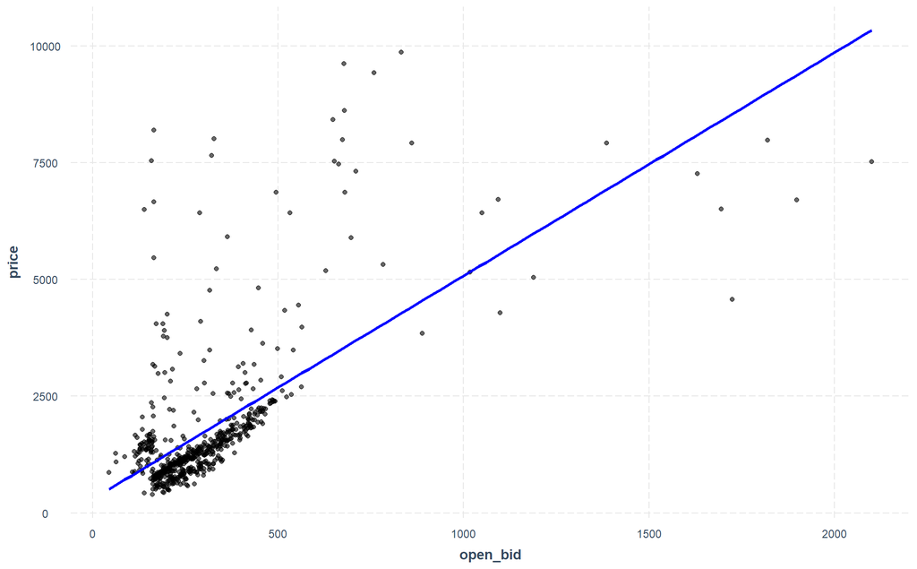

```r
# Create the effect plot
mod_1_plot <- effect_plot(
  # model
  mod_1,
  # predictor
  pred = "open_bid",
  # line color
  line.col = "blue",
  # points
  plot.points = TRUE,
  # interval
  ci.style = "bands",
  # x-axis label
  xlab = "Opening Bid Price",
  # y-axis label
  ylab = "Final Price"
)

# Adjust axis labels
mod_1_plot$xlab <- label_dollar(mod_1_plot$xlab)
mod_1_plot$ylab <- label_dollar(mod_1_plot$ylab)

# View the plot
mod_1_plot
```

## Task 4.4

Examine the *levels* of **auction_type** by calling **auction_work**, piping to pull **auction_type**, and piping the result to **levels()**.

Examine the *contrasts* of **auction_type** by calling **auction_work**, piping to pull **auction_type**, and piping the result to **contrasts()**.

Estimate an OLS regression model named **mod_2** using **lm()**. Predict values of **price** from values of **auction_type**. Set the *data* input to **auction_work**.

Use **glance()**, **tidy()**, and **summ()** to review the content of **mod_2**.

**Question 4.4**: Answer these questions: (1) What is the *last* level of *auction type*? (2) Which level of *auction type* serves as the *referent* category? (3) What is the *mean difference* of *final price* between the *5 day auction* and the *3 day auction*? (4) What is the *mean difference* of *final price* between the *7 day auction* and the *3 day auction*?

**Response 4.4**: (1) 7 day auction (2) 3 day auction (3) $321.12 (4) $343.93

```r
auction_work %>%
  pull(auction_type) %>%
  levels()
```

```
## [1] "3 Day Auction" "5 Day Auction" "7 Day Auction"
```

```r
auction_work %>%
  pull(auction_type) %>%
  contrasts()
```

```
##               5 Day Auction 7 Day Auction
## 3 Day Auction             0             0
## 5 Day Auction             1             0
## 7 Day Auction             0             1
```

```r
mod_2 <- lm(price ~ auction_type, data = auction_work)

# Review the content of mod_2 using glance(), tidy(), and summ()
glance(mod_2)
```

| r.squared | adj.r.squared | sigma | statistic | p.value | df | logLik | AIC | BIC | deviance | df.residual | nobs |
| --- | --- | --- | --- | --- | --- | --- | --- | --- | --- | --- | --- |
| 0.008830222 | 0.005653396 | 1532.798 | 2.779574 | 0.06283361 | 2 | -5487.122 | 10982.24 | 11000.01 | 1466069761 | 624 | 627 |

```r
tidy(mod_2)
```

| term | estimate | std.error | statistic | p.value |
| --- | --- | --- | --- | --- |
| (Intercept) | 1485.0172 | 125.9952 | 11.786295 | 4.322089e-29 |
| auction_type5 Day Auction | 321.1182 | 200.8693 | 1.598643 | 1.104062e-01 |
| auction_type7 Day Auction | 343.9309 | 148.3549 | 2.318297 | 2.075551e-02 |

```r
## succinct summary
summ(mod_2)
```

```
## MODEL INFO:
## Observations: 627
## Dependent Variable: price
## Type: OLS linear regression
##
## MODEL FIT:
## F(2,624) = 2.78, p = 0.06
## R² = 0.01
## Adj. R² = 0.01
##
## Standard errors: OLS
## ------------------------------------------------------------------
##                                      Est.     S.E.   t val.      p
## ------------------------------- --------- -------- -------- ------
## (Intercept)                       1485.02   126.00    11.79   0.00
## auction_type5 Day Auction          321.12   200.87     1.60   0.11
## auction_type7 Day Auction          343.93   148.35     2.32   0.02
## ------------------------------------------------------------------
```

## Task 4.5

Create a new data table named **mod_2_results** using **augment()**. Set the *model* input to **mod_2** and the *data* input to **auction_work**. Pipe the result to **select()** and select for **auction_type**, **price**, **price_fit = .fitted**, and **price_resid = .resid**.

Print the table.

**Question 4.5**: Answer these questions: (1) Does the model *over* or *under* predict the actual *price* value for the *sixth* auction? (2) Does the model *over* or *under* predict the actual *price* value for the *ninth* auction?

```r
mod_2_results <- augment(mod_2, data = auction_work) %>%
  select(auction_type, price, price_fit = .fitted, price_resid = .resid)

# Print the table
mod_2_results
```

| auction_type | price | price_fit | price_resid |
| --- | --- | --- | --- |
| 7 Day Auction | 7316.87 | 1828.948 | 5487.921984 |
| 7 Day Auction | 2557.03 | 1828.948 | 728.081984 |
| 7 Day Auction | 4816.48 | 1828.948 | 2987.531984 |
| 7 Day Auction | 2911.76 | 1828.948 | 1082.811984 |
| 3 Day Auction | 1495.36 | 1485.017 | 10.342838 |
| 7 Day Auction | 1153.17 | 1828.948 | -675.778016 |
| 7 Day Auction | 7468.26 | 1828.948 | 5639.311984 |
| 7 Day Auction | 2409.51 | 1828.948 | 580.561984 |
| 7 Day Auction | 1662.76 | 1828.948 | -166.188016 |
| 7 Day Auction | 745.09 | 1828.948 | -1083.858016 |

[output cut: 617 more lines]

## Task 4.6

Create a plot named **mod_2_plot** using **effect_plot()**. Set **mod_2** as the *model* input and **auction_type** as the **pred** input. Color the regression line *blue* and do *not* include the *data points* but do include the *standard error interval*. Set the *x-axis title* to **“Auction Type”** and the *y-axis title* to **“Final Price”**. Adjust the *y-axis* labels by applying **label_dollar()**.

View **mod_2_plot**.

**Question 4.6**: Answer these questions: (1) Do the standard error intervals for the *3 day auction* and the *5 day auction* overlap? (2) Approximately, what is the *point estimate* of the *final price* for the *5 day auction*?

**Response 4.6**: (1) Yes (2) ~$1810

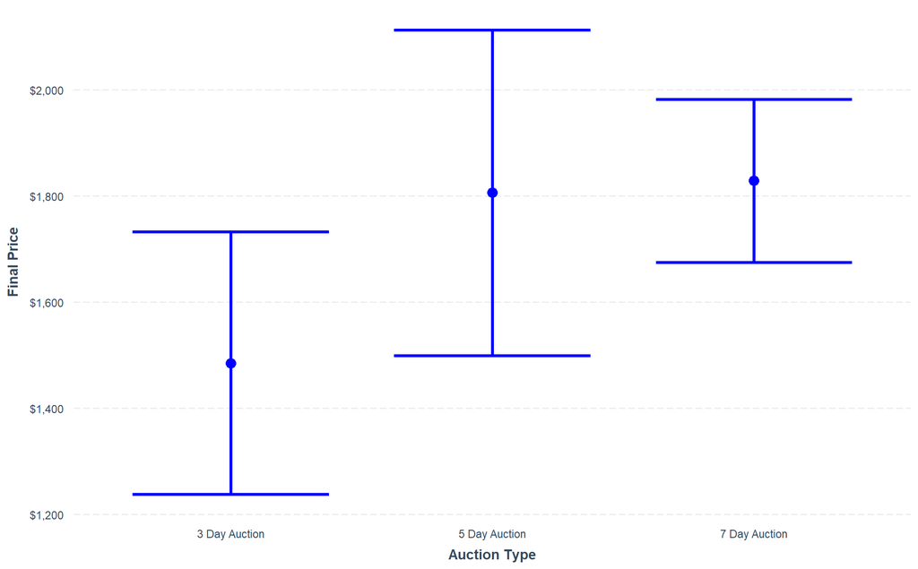

```r
mod_2_plot <- effect_plot(
  # model
  mod_2,
  # predictor
  pred = auction_type,
  # line color
  line.colors = "blue",
  # points
  plot.points = FALSE,
  # interval
  interval = TRUE,
  # x-axis label
  x.label = "Auction Type",
  # y-axis label
  y.label = "Final Price"
) +
  ## y-axis scale
  scale_y_continuous(
    # labels in dollars
    labels = label_dollar()
  )

## show plot
mod_2_plot
```

# Task 5: Fit Regression Model with Two Predictors

In this task, you will fit regression models with two predictors and explore interaction effects.

## Task 5.1

Calculate three set of computations.

First, estimate an OLS regression model named **mod_3** using **lm()**. Predict values of **price** from values of **auction_type** and **open_bid_cent**. Set the *data* input to **auction_work**. Use **summ()** to view the results.

Second, estimate an OLS regression model named **mod_4** using **lm()**. Predict values of **price** from values of **auction_type**, **open_bid_cent**, and their *interaction effect*. Set the *data* input to **auction_work**. Use **glance()**, **tidy()**, and **summ()** to review the content of **mod_4**.

Third, use **glance()** to calculate the *R-squared* difference between **mod_3** and **mod_4**. Use **anova()** to perform an *F-test* on the change in *R-squared*.

**Question 5.1**: Answer these questions: (1) What is the *interaction* estimate between *centered opening bid price* and the *5 day auction*? (2) What is the *R-squared difference* between the two models? (3) What is the *F-value* of the *R-squared difference*?

**Response 5.1**: (1) -.503 (2) .000654 (3) .3589

```r
# First computation
mod_3 <- lm(price ~ auction_type + open_bid_cent, data = auction_work)
summ(mod_3)
```

```
## MODEL INFO:
## Observations: 627
## Dependent Variable: price
## Type: OLS linear regression
##
## MODEL FIT:
## F(3,623) = 158.69, p = 0.00
## R² = 0.43
## Adj. R² = 0.43
##
## Standard errors: OLS
## ------------------------------------------------------------------
##                                      Est.     S.E.   t val.      p
## ------------------------------- --------- -------- -------- ------
## (Intercept)                       1480.14    95.36    15.52   0.00
## auction_type5 Day Auction          235.12   152.08     1.55   0.12
## auction_type7 Day Auction          373.46   112.29     3.33   0.00
## open_bid_cent                        4.79     0.22    21.60   0.00
## ------------------------------------------------------------------
```

```r
# Second computation
mod_4 <- lm(price ~ auction_type * open_bid_cent, data = auction_work)
glance(mod_4)
```

| r.squared | adj.r.squared | sigma | statistic | p.value | df | logLik | AIC | BIC | deviance | df.residual | nobs |
| --- | --- | --- | --- | --- | --- | --- | --- | --- | --- | --- | --- |
| 0.433806 | 0.4292473 | 1161.288 | 95.15944 | 2.35211e-74 | 5 | -5311.578 | 10637.16 | 10668.24 | 837474996 | 621 | 627 |

```r
tidy(mod_4)
```

| term | estimate | std.error | statistic | p.value |
| --- | --- | --- | --- | --- |
| (Intercept) | 1479.5854923 | 95.4600515 | 15.4995254 | 4.789566e-46 |
| auction_type5 Day Auction | 234.7845303 | 152.5177586 | 1.5393914 | 1.242181e-01 |
| auction_type7 Day Auction | 373.5809131 | 112.4079388 | 3.3234389 | 9.414216e-04 |
| open_bid_cent | 5.3405577 | 0.7091790 | 7.5306199 | 1.787934e-13 |
| auction_type5 Day Auction:open_bid_cent | -0.5028451 | 0.8855817 | -0.5678133 | 5.703669e-01 |
| auction_type7 Day Auction:open_bid_cent | -0.6357479 | 0.7555068 | -0.8414853 | 4.004000e-01 |

```r
summ(mod_4)
```

```
## MODEL INFO:
## Observations: 627
## Dependent Variable: price
## Type: OLS linear regression
##
## MODEL FIT:
## F(5,621) = 95.16, p = 0.00
## R² = 0.43
## Adj. R² = 0.43
##
## Standard errors: OLS
## ------------------------------------------------------------------
##                                      Est.     S.E.   t val.      p
## ------------------------------- --------- -------- -------- ------
## (Intercept)                       1479.59    95.46    15.50   0.00
## auction_type5 Day Auction          234.78   152.52     1.54   0.12
## auction_type7 Day Auction          373.58   112.41     3.32   0.00
## open_bid_cent                        5.34     0.71     7.53   0.00
## auction_type5 Day                   -0.50     0.89    -0.57   0.57
## Auction:open_bid_cent
## auction_type7 Day                   -0.64     0.76    -0.84   0.40
## Auction:open_bid_cent
## ------------------------------------------------------------------
```

```r
# Third computation
glance(mod_4)$r.squared - glance(mod_3)$r.squared
```

```
## [1] 0.0006543883
```

```r
anova(mod_3, mod_4)
```

|  | Res.Df | RSS | Df | Sum of Sq | F | Pr(>F) |
| --- | --- | --- | --- | --- | --- | --- |
| 1 | 623 | 838442922 | NA | NA | NA | NA |
| 2 | 621 | 837474996 | 2 | 967925.9 | 0.3588656 | 0.6986129 |

## Task 5.2

Create a new data table named **mod_4_results** using **augment()**. Set the *model* input to **mod_4** and the *data* input to **auction_work**. Pipe the result to **select()** and select for **open_bid_cent**, **auction_type**, **price**, **price_fit = .fitted**, and **price_resid = .resid**.

Print the table.

**Question 5.2**: Answer these questions: (1) What is the *difference* between the *observed* and *fitted* value of *price* for the *third* auction? (2) Does the model *over* or *under* predict the actual *price* value for the *tenth* auction?

```r
mod_4_results <- augment(mod_4, data = auction_work) %>%
  select(open_bid_cent, auction_type, price, price_fit = .fitted, price_resid = .resid)

# Print the table
mod_4_results
```

| open_bid_cent | auction_type | price | price_fit | price_resid |
| --- | --- | --- | --- | --- |
| 408.07800638 | 7 Day Auction | 7316.87 | 3773.0958 | 3543.7742120 |
| 21.99800638 | 7 Day Auction | 2557.03 | 1956.6628 | 600.3671598 |
| 144.89800638 | 7 Day Auction | 4816.48 | 2534.8840 | 2281.5960417 |
| 206.14800638 | 7 Day Auction | 2911.76 | 2823.0536 | 88.7064445 |
| 75.13800638 | 3 Day Auction | 1495.36 | 1880.8643 | -385.5043488 |
| -51.04199362 | 7 Day Auction | 1153.17 | 1613.0235 | -459.8535362 |
| 361.04800638 | 7 Day Auction | 7468.26 | 3551.8286 | 3916.4314144 |
| 184.81800638 | 7 Day Auction | 2409.51 | 2722.7000 | -313.1899635 |
| -187.12199362 | 7 Day Auction | 1662.76 | 972.7930 | 689.9669745 |
| -120.83199362 | 7 Day Auction | 745.09 | 1284.6749 | -539.5848638 |

[output cut: 617 more lines]

## Task 5.3

Create a plot named **mod_4_plot** using **interact_plot()**. Set **mod_4** as the *model* input and **open_bid_cent** as the **pred** input and **auction_type** as the **modx** input. Color the regression lines with **“Set1”**, do *not* include the *data points*, and set *line thickness* to **2**. Set the *x-axis title* to **“Opening Bid Price”**, the *y-axis title* to **“Final Price”**, and the *legend* to **“Auction Type”**. Adjust the *x-axis* and *y-axis* labels by applying **label_dollar()**. View **mod_4_plot**.

Call **sim_slopes()**. Set **mod_4** as the *model* input and **open_bid_cent** as the **pred** input and **auction_type** as the **modx** input.

**Question 5.3**: Answer these questions: (1) What is the *simple slope estimate* for the *3 day auction*? (2) Looking at the plot, which *auction type* predicts the *highest final price* when the *centered opening bid price* is `$1,500`?

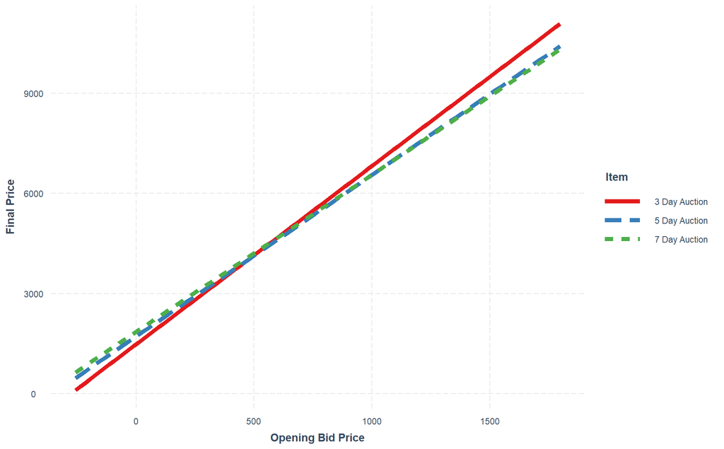

```r
mod_4_plot <- interact_plot(mod_4, pred = open_bid_cent, modx = auction_type, plot.points = FALSE, line.thickness = 2, x.label = "Opening Bid Price", y.label = "Final Price", legend.main = "Item", colors = "Set1")

## print plot
mod_4_plot
```

```r
sim_slopes(mod_4, pred = open_bid_cent, modx = auction_type)
```

```
## SIMPLE SLOPES ANALYSIS
##
## Slope of open_bid_cent when auction_type = 7 Day Auction:
##
##   Est.   S.E.   t val.      p
## ------ ------ -------- ------
##   4.70   0.26    18.06   0.00
##
## Slope of open_bid_cent when auction_type = 5 Day Auction:
##
##   Est.   S.E.   t val.      p
## ------ ------ -------- ------
##   4.84   0.53     9.12   0.00
##
## Slope of open_bid_cent when auction_type = 3 Day Auction:
##
##   Est.   S.E.   t val.      p
## ------ ------ -------- ------
##   5.34   0.71     7.53   0.00
```

## Task 5.4

Calculate three set of computations.

First, estimate an OLS regression model named **mod_5** using **lm()**. Predict values of **price** from values of **bid_cent** and **open_bid_cent**. Set the *data* input to **auction_work**. Use **summ()** to view the results.

Second, estimate an OLS regression model named **mod_6** using **lm()**. Predict values of **price** from values of **bid_cent**, **open_bid_cent**, and their *interaction effect*. Set the *data* input to **auction_work**. Use **glance()**, **tidy()**, and **summ()** to review the content of **mod_6**.

Third, use **glance()** to calculate the *R-squared* difference between **mod_5** and **mod_6**. Use **anova()** to perform an *F-test* on the change in *R-squared*.

**Question 5.4**: Answer these questions: (1) What is the *interaction* estimate between *centered bid price* and *centered opening bid price*? (2) What is the *R-squared difference* between the two models? (3) What is the *F-value* of the *R-squared difference*?

**Response 5.4**: (1) -.00115 (2) .03118985 (3) 128.59

```r
mod_5 <- lm(price ~ bid_cent + open_bid_cent, data = auction_work)
summ(mod_5)
```

```
## MODEL INFO:
## Observations: 627
## Dependent Variable: price
## Type: OLS linear regression
##
## MODEL FIT:
## F(2,624) = 1399.45, p = 0.00
## R² = 0.82
## Adj. R² = 0.82
##
## Standard errors: OLS
## -----------------------------------------------------
##                          Est.    S.E.   t val.      p
## ------------------- --------- ------- -------- ------
## (Intercept)           1744.27   26.25    66.44   0.00
## bid_cent                 1.63    0.04    36.76   0.00
## open_bid_cent            2.11    0.15    14.53   0.00
## -----------------------------------------------------
```

```r
# Second computation
mod_6 <- lm(price ~ bid_cent * open_bid_cent, data = auction_work)
glance(mod_6)
```

| r.squared | adj.r.squared | sigma | statistic | p.value | df | logLik | AIC | BIC | deviance | df.residual | nobs |
| --- | --- | --- | --- | --- | --- | --- | --- | --- | --- | --- | --- |
| 0.8488882 | 0.8481606 | 598.9746 | 1166.592 | 4.127428e-255 | 3 | -4897.471 | 9804.941 | 9827.146 | 223514086 | 623 | 627 |

```r
tidy(mod_6)
```

| term | estimate | std.error | statistic | p.value |
| --- | --- | --- | --- | --- |
| (Intercept) | 1.826814e+03 | 25.003724645 | 73.06168 | 9.984363e-308 |
| bid_cent | 1.693458e+00 | 0.040798367 | 41.50799 | 1.592728e-181 |
| open_bid_cent | 4.002029e+00 | 0.213013380 | 18.78769 | 9.924462e-63 |
| bid_cent:open_bid_cent | -1.153122e-03 | 0.000101689 | -11.33970 | 3.160662e-27 |

```r
summ(mod_6)
```

```
## MODEL INFO:
## Observations: 627
## Dependent Variable: price
## Type: OLS linear regression
##
## MODEL FIT:
## F(3,623) = 1166.59, p = 0.00
## R² = 0.85
## Adj. R² = 0.85
##
## Standard errors: OLS
## --------------------------------------------------------------
##                                   Est.    S.E.   t val.      p
## ---------------------------- --------- ------- -------- ------
## (Intercept)                    1826.81   25.00    73.06   0.00
## bid_cent                          1.69    0.04    41.51   0.00
## open_bid_cent                     4.00    0.21    18.79   0.00
## bid_cent:open_bid_cent           -0.00    0.00   -11.34   0.00
## --------------------------------------------------------------
```

```r
# Third computation
glance(mod_6)$r.squared - glance(mod_5)$r.squared
```

```
## [1] 0.03118985
```

```r
anova(mod_5, mod_6)
```

|  | Res.Df | RSS | Df | Sum of Sq | F | Pr(>F) |
| --- | --- | --- | --- | --- | --- | --- |
| 1 | 624 | 269647950 | NA | NA | NA | NA |
| 2 | 623 | 223514086 | 1 | 46133865 | 128.5888 | 3.160662e-27 |

## Task 5.5

Create a new data table named **mod_6_results** using **augment()**. Set the *model* input to **mod_6** and the *data* input to **auction_work**. Pipe the result to **select()** and select for **bid_cent**, **open_bid_cent**, **auction_type**, **price**, **price_fit = .fitted**, and **price_resid = .resid**.

Print the table.

**Question 5.5**: Answer these questions: (1) What is the *difference* between the *observed* and *fitted* value of *price* for the *fifth* auction? (2) Does the model *over* or *under* predict the actual *price* value for the *seventh* auction?

**Response 5.5**: (1) -181 (2) 602

```r
mod_6_results <- augment(mod_6, data = auction_work) %>%
  select(bid_cent, open_bid_cent, auction_type, price, price_fit = .fitted, price_resid = .resid)

# Print the table
mod_6_results
```

| bid_cent | open_bid_cent | auction_type | price | price_fit | price_resid |
| --- | --- | --- | --- | --- | --- |
| 2614.405901 | 408.07800638 | 7 Day Auction | 7316.87 | 6657.0968 | 659.773221 |
| 364.405901 | 21.99800638 | 7 Day Auction | 2557.03 | 2522.7134 | 34.316641 |
| 844.405901 | 144.89800638 | 7 Day Auction | 4816.48 | 3695.5787 | 1120.901258 |
| 4.405901 | 206.14800638 | 7 Day Auction | 2911.76 | 2658.2384 | 253.521608 |
| -280.594099 | 75.13800638 | 3 Day Auction | 1495.36 | 1676.6559 | -181.295866 |
| -185.594099 | -51.04199362 | 7 Day Auction | 1153.17 | 1297.3231 | -144.153110 |
| 2814.405901 | 361.04800638 | 7 Day Auction | 7468.26 | 6866.0892 | 602.170766 |
| -125.594099 | 184.81800638 | 7 Day Auction | 2409.51 | 2380.5392 | 28.970794 |
| 114.385901 | -187.12199362 | 7 Day Auction | 1662.76 | 1296.3358 | 366.424223 |
| -265.594099 | -120.83199362 | 7 Day Auction | 745.09 | 856.4622 | -111.372152 |

[output cut: 617 more lines]

## Task 5.6

Create a plot named **mod_6_plot** using **interact_plot()**. Set **mod_6** as the *model* input and **bid_cent** as the **pred** input and **open_bid_cent** as the **modx** input. Color the regression lines with **“Set1”**, do *not* include the *data points*, and set *line thickness* to **2**. Set the *x-axis title* to **“Opening Bid Price”**, the *y-axis title* to **“Final Price”**, and the *legend* to **“Opening Bid Price”**. Adjust the *x-axis* and *y-axis* labels by applying **label_dollar()**. View **mod_6_plot**.

Call **sim_slopes()**. Set **mod_6** as the *model* input and **bid_cent** as the **pred** input and **open_bid_cent** as the **modx** input.

**Question 5.6**: Answer these questions: (1) What is the *simple slope estimate* for the *middle tercile median* of *centered opening bid price*? (2) Looking at the plot, which *tercile median* of *centered opening bid price* predicts the *highest final price* when the *centered bid price* is `$1,000`?

[figure not shown]

```r
## call function
mod_6_plot <- interact_plot(
  ## specify model
  mod_6,
  ## specify x-axis variable
  pred = bid_cent,
  ## specify moderator variable
  modx = open_bid_cent,
  ## choose moderator values
  modx.values = "terciles",
  ## Include points
  plot.points = FALSE,
  ## line thickness
  line.thickness = 2,
  ## x-axis label
  x.label = "Opening Bid Price",
  ## y-axis label
  y.label = "Final Price",
  ## legend label
  legend.main = "Opening Bid Price",
  ## legend labels
  modx.labels = c(
    # lower tercile label
    "Lower Tercile Median",
    # middle tercile label
    "Middle Tercile Median",
    # upper tercile label
    "Upper Tercile Median"
  ),
  ## colors
  colors = "Set1"
) +
  ## x-axis scale
  scale_x_continuous(
    # breaks
    breaks = seq(-6, 2, 1)
  ) +
  ## change y-axis scale
  scale_y_continuous(
    # change labels to dollars
    labels = label_dollar()
  ) +
  ## update theme
  theme(
    # legend to bottom
    legend.position = "bottom"
  )

## print plot
mod_6_plot
```

```r
sim_slopes(mod_6, pred = bid_cent, modx = open_bid_cent)
```

```
## JOHNSON-NEYMAN INTERVAL
##
## When open_bid_cent is OUTSIDE the interval [1250.39, 1774.21], the slope of
## bid_cent is p < .05.
##
## Note: The range of observed values of open_bid_cent is [-258.01, 1797.97]
##
## SIMPLE SLOPES ANALYSIS
##
## Slope of bid_cent when open_bid_cent = -2.091917e+02 (- 1 SD):
##
##   Est.   S.E.   t val.      p
## ------ ------ -------- ------
##   1.93   0.05    39.88   0.00
##
## Slope of bid_cent when open_bid_cent = -1.028984e-14 (Mean):
##
##   Est.   S.E.   t val.      p
## ------ ------ -------- ------
##   1.69   0.04    41.51   0.00
##
## Slope of bid_cent when open_bid_cent =  2.091917e+02 (+ 1 SD):
##
##   Est.   S.E.   t val.      p
## ------ ------ -------- ------
##   1.45   0.04    33.49   0.00
```

# Task 6: Save Objects

For this task, you will save the plots and the working data. First, save the working data, **auction_work** as the data file: **auction_work.fst** in the **data** folder of the project directory using **write_fst()**.

Second, save the three plot objects as **png** files in the **plots** folder of the project directory using the combination of **walk()**, **ls()**, **ggsave()**, **here()**, **str_glue()**, **str_remove()**, and **get()**. Use a width of *8.1 inches* and a height of *5 inches*.

```r
write_fst(
  ## name of object
  auction_work,
  ## use here() to export data to project directory
  here(
    # folder
    "data",
    # file
    "auction_work.fst"
  )
)

### save plots
## call function
walk(
  ## vector of plots
  ls(
    # name pattern
    pattern = "plot"
  ),
  ## function
  function(plot_inp) {
    ### save plot
    ## call function
    ggsave(
      ## file path
      here(
        # folder
        "plots",
        # file
        str_glue(
          # remove string
          str_remove(
            # string
            plot_inp,
            # pattern
            "_plot"
          ),
          # extension
          ".png"
        )
      ),
      ## plot object
      plot = get(plot_inp),
      ## units
      units = "in",
      ## width
      width = 8.1,
      ## height
      height = 5
    )
  }
)
```

# Task 7: Conceptual Questions

For your last task, you will respond to conceptual questions based on the conceptual lectures for this week.

**Question 7.1**: What is the purpose of the least-squares criterion in regression?

**Response 7.1**: The least-squares criterion in regression is used to find the best-fitting line through a set of data points. It minimizes the sum of the squares of the differences between the observed values and the values predicted by the regression model. In other words, it finds the line that minimizes the overall distance between the data points and the line.

**Question 7.2**: What is a residual value from an OLS regression model?

**Response 7.2**: A residual value from an OLS (Ordinary Least Squares) regression model is the difference between the observed value of the dependent variable and the value predicted by the regression model. In other words, it is the vertical distance between the data point and the regression line.

**Question 7.3**: What does an interaction effect of two predictors indicate about the relationship between them and the outcome?

**Response 7.3**: An interaction effect of two predictors in a regression model indicates that the effect of one predictor on the outcome variable depends on the value of the other predictor. In other words, the relationship between one predictor and the outcome variable is different depending on the value of the other predictor. This interaction effect can reveal more complex relationships in the data that cannot be captured by considering each predictor separately.